# (Kaggle) Titanic: Machine Learning from Disaster

## 시작하기 전에

타이타닉 해상사고 데이터 분석을 진행하기 전에 파이썬을 처음 사용하신다면 아래의 링크를 추천드립니다.

- 파이썬 기본서(E-book) 및 라이브러리 site.
  1. 점프 투 파이썬 : [JumpToPython](https://wikidocs.net/book/1)
  2. 코딩도장 : [Dojang.io](https://dojang.io)
  3. 판다스 : [Pandas](http://pandas.pydata.org/pandas-docs/stable/getting_started/10min.html)
- 파이썬 설치 및 PIP 설치 링크
  1. 파이썬 공식 홈페이지 : [python](https://www.python.org/downloads/) (추후 딥러닝 등의 사용을 위해 Tensorflow 등을 사용한다 한다면 3.7버전이 아닌 3.6버전 설치 권장)
  2. PIP 설치(윈도우) : [pipwindows](http://doocong.com/python/python-pip-install/) (wget이 먹히지 않으면 직접 다운로드 후 실행할 것을 권장)
  3. PIP 설치(리눅스, 맥) : [piplinuxmac](https://www.shellhacks.com/python-install-pip-mac-ubuntu-centos/) (각 환경에 맞춰 구체적 방법을 블로그에 업로드 할 예정)

     ** 수동으로 PIP 및 각종 패키지 설치가 어려우신 분들을 Anaconda 설치 후 바로 진행하셔도 됩니다.
  4. Anaconda 설치 : [Anaconda](https://www.anaconda.com/distribution/) (해당 플랫폼을 설치하면 PIP를 통해 필요한 패키지를 수동으로 설치해줄 필요가 없음)
- 설치한 PIP 리스트
  1. pip install numpy
  2. pip install scipy
  3. pip install pandas
  4. pip install scikit-learn
  5. pip install matplotlib
  6. pip install seaborn
  7. pip install jupyter

## 데이터 설명 및 로드(Data Description & Loading)

- 해당 링크 참조 [Kaggle_Titanic Data Description](https://www.kaggle.com/c/titanic/data)

```python
# Pandas를 사용하여 Titanic raw data 불러오기
import pandas as pd

# train 변수에 불러온 csv 파일을 index_col을 지정해 저장합니다
train = pd.read_csv("data/train.csv", index_col="PassengerId")

# train 변수에 할당된 데이터 행렬의 크기를 확인
# 저장된 데이터의 행렬수를 확인해서, 내가 변경하고 튜닝한 데이터가 제대로 맞게 들어갔는지 확인합니다.
print(train.shape)

# head()를 사용하면 train 데이터의 상위 5개를 볼 수 있습니다.
train.head()

# 블로그 화면 크기에 맞춰 들어갈 수 있도록 Jupyter notebook 크기 수정
# Output이 짤려요 막... ㅠㅠ
from IPython.core.display import display, HTML
display(HTML("<style>.container { width: 97% !important; }</style>"))

from IPython.core.interactiveshell import InteractiveShell
InteractiveShell.ast_node_interactivity = "all"
```

```
(891, 11)
```

| PassengerId | Survived | Pclass | Name | Sex | Age | SibSp | Parch | Ticket | Fare | Cabin | Embarked |
| --- | --- | --- | --- | --- | --- | --- | --- | --- | --- | --- | --- |
| 1 | 0 | 3 | Braund, Mr. Owen Harris | male | 22.0 | 1 | 0 | A/5 21171 | 7.2500 | NaN | S |
| 2 | 1 | 1 | Cumings, Mrs. John Bradley (Florence Briggs Th... | female | 38.0 | 1 | 0 | PC 17599 | 71.2833 | C85 | C |
| 3 | 1 | 3 | Heikkinen, Miss. Laina | female | 26.0 | 0 | 0 | STON/O2. 3101282 | 7.9250 | NaN | S |
| 4 | 1 | 1 | Futrelle, Mrs. Jacques Heath (Lily May Peel) | female | 35.0 | 1 | 0 | 113803 | 53.1000 | C123 | S |
| 5 | 0 | 3 | Allen, Mr. William Henry | male | 35.0 | 0 | 0 | 373450 | 8.0500 | NaN | S |

```python
# test 데이터도 같은 방식으로 진행합니다.
test = pd.read_csv("data/test.csv", index_col="PassengerId")

# 제대로 test 데이터가 할당되어 있는지 확인합니다.
print(test.shape)

# 상위 5개 출력하여 test 데이터의 형태를 살펴봅니다.
test.head()
```

```
(418, 10)
```

| PassengerId | Pclass | Name | Sex | Age | SibSp | Parch | Ticket | Fare | Cabin | Embarked |
| --- | --- | --- | --- | --- | --- | --- | --- | --- | --- | --- |
| 892 | 3 | Kelly, Mr. James | male | 34.5 | 0 | 0 | 330911 | 7.8292 | NaN | Q |
| 893 | 3 | Wilkes, Mrs. James (Ellen Needs) | female | 47.0 | 1 | 0 | 363272 | 7.0000 | NaN | S |
| 894 | 2 | Myles, Mr. Thomas Francis | male | 62.0 | 0 | 0 | 240276 | 9.6875 | NaN | Q |
| 895 | 3 | Wirz, Mr. Albert | male | 27.0 | 0 | 0 | 315154 | 8.6625 | NaN | S |
| 896 | 3 | Hirvonen, Mrs. Alexander (Helga E Lindqvist) | female | 22.0 | 1 | 1 | 3101298 | 12.2875 | NaN | S |

## 탐험적 데이터 분석(Exploratory Data Analysis)

데이터를 머신러닝에 적용하기 전 데이터 분석을 진행해보겠습니다. 스프레드시트(엑셀) 기반에선 주로 피벗 테이블과, 차트 등을 그려 시각, 직관, 배경지식등을 동원하여 가설을 세우고 의미있는 feature들을 골라내는 작업을 했었습니다. 이번에도 비슷한 방식으로 진행하지만, 여러 파이썬 패키지들을 이용하여 스프레드시트에서 분석을 진행하지 못했던 부분까지 같이 진행해 보도록 하겠습니다.

`pip`로 설치한 패키지들 중 `matplotlib(파이썬 2D 플로팅 패키지)`과 `seaborn(matplotlib기반 파이썬 데이터 시각화 패키지)`등을 사용해 보겠습니다.

- 참고링크([matplotlib](https://matplotlib.org/gallery/index.html), [seaborn](https://seaborn.pydata.org/))

```python
# matplotlib의 결과 그래프는 inline 선언이 선행되어야 합니다
# 현재 사용하고 있는 브라우저에 떠 있는 jupyter notebook에 그래프를 띄우기 위함(magic function)
%matplotlib inline

# seaborn 패키지 로딩
import seaborn as sns

# matplotlib 패키지 로딩
import matplotlib.pyplot as plt
```

### Sex(성별) Feature 분석

앞 포스트에서 언급했다시피 `Sex feature`가 특히 눈에 띄게 생존자와 사망자를 구분지어 주었습니다. 이전에 그래프를 그렸던 것 처럼 이번에도 그래프를 그려 데이터 시각화를 진행해 보겠습니다.

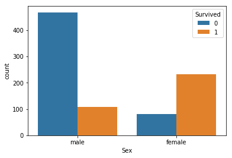

```python
# 타이타닉 train 데이터를 이용 seaborn 패키지의 countplot 사용
# countplot : 각 category별 관측 수를 barplot 기반으로 보여줌
# 참조 : (https://seaborn.pydata.org/generated/seaborn.countplot.html#seaborn.countplot)
sns.countplot(data=train, x="Sex", hue="Survived")
```

```python
# 해당 데이터를 pivot_data로 나타냄
# pandas pivot table 참조 : https://pandas.pydata.org/pandas-docs/stable/reference/api/pandas.pivot_table.html
pd.pivot_table(train, index="Sex", values="Survived")
```

| Sex | Survived |
| --- | --- |
| female | 0.742038 |
| male | 0.188908 |

`countplot` 및 `pivot table`로 분석을 해보면 다음과 같은 사실을 알 수 있습니다. 여성의 생존률이 *74.2%* 이고 남성의 생존률은 *18.9%* 이며 이 말은 여성의 생존률이 남성의 생존률 보다 월등히 높음을 알 수 있습니다.

이전에도 `pivot table`과 `countplot`을 동시에 그렸는데 수치를 확인하는 `pivot table`과 `countplot`은 각각의 장단이 있습니다.

- 그래프 등을 통한 분석은 구체적 수치를 알기 어려우나 한눈에 변화 추이를 확인 하기 쉽습니다.
- 피벗 테이블을 통한 분석은 구체적 수치를 알기 쉽지만 그 수치가 어떤 변화를 뜻하는지 알기 어렵습니다.

따라서 데이터 분석을 진행할때는 두개 다 활용하는 것이 좋습니다.

### Pclass(승선 티켓 등급) Feature 분석

`Pclass` 또한 `Sex feature`와 단순히 같이 썼을 땐 유의미한 결과를 도출하는데 어려움은 있었으나 어느정도 유의미한 데이터 결과를 보여줬습니다 그래서 이번에 그래프 피벗 테이블을 같이 이용하여 다시 분석해 보도록 하겠습니다.

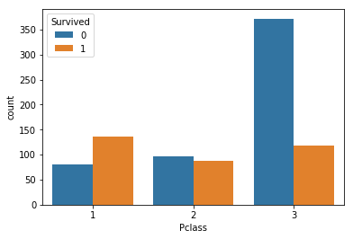

```python
# countplot을 이용하여 Pclass별 생존률을 확인
sns.countplot(data=train, x="Pclass", hue="Survived")
```

```python
# pivot table로 해당 Feature의 생존률을 나타냄
pd.pivot_table(train, index="Pclass", values="Survived")
```

| Pclass | Survived |
| --- | --- |
| 1 | 0.629630 |
| 2 | 0.472826 |
| 3 | 0.242363 |

예상대로 1등급 승객의 생존률이 사망률보다 높고, 나머지 2, 3등급 순으로 생존률이 높다.

- 1등급의 승객의 생존률만 사망률보다 높고 2, 3등급의 생존률은 사망률보다 낮다
- 3등급의 승객이 압도적으로 사망률이 높다
- 피벗 테이블을 확인해 보면 구체적인 수치를 확인 가능하다(1등급 : *62%*, 2등급 : *47%*, 3등급 : *24%*)

### Embarked(탑승 선착장) Feature 분석

탑승한 선착장(`Embarked`)에 따른 생존률을 분석을 진행해 보겠습니다.

- 세르부르(Cherbourg, C)
- 퀸스타운(Queenstown, Q)
- 사우스햄튼(Southampton, S)

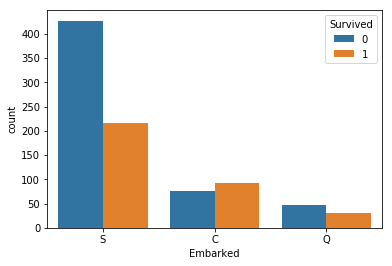

```python
# countplot을 이용한 Embarked 그래프 시각화
sns.countplot(data=train, x="Embarked", hue="Survived")
```

```python
# pivot table로 해당 Feature의 생존률을 나타냄
pd.pivot_table(train, index="Embarked", values="Survived")
```

| Embarked | Survived |
| --- | --- |
| C | 0.553571 |
| Q | 0.389610 |
| S | 0.336957 |

분석해보면 역시 S 선착장에서 탑승한 승객의 사망률이 가장 높게 나타나고 탑승 승객의 인원수도 가장 많은 것을 확인해 볼 수 있습니다.(이전 분석에서 역시 이 사실을 이용하여 feature로 사용)

### Age(연령) Feature 분석

이번엔 이전에 분석하지 않았던 feature들에 대해서도 분석해 보도록 하겠습니다. 타이타닉에 탑승한 승객들의 연령대와 생존여부에 관한 상관여부를 분석해 볼건데, 기존 분석처럼 countplot을 사용해보고 뚜렷한 경향을 확인하기 어려우면 seaborn에 있는 다른 plot을 한번 사용하여 진행해 보도록 하겠습니다.

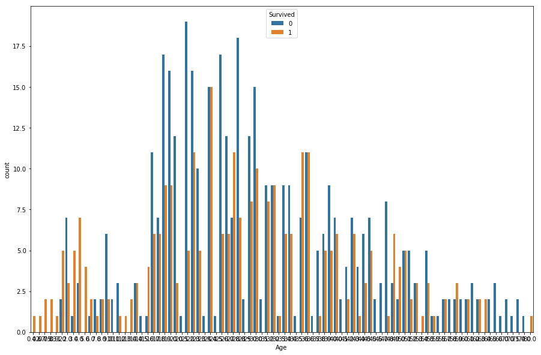

```python
# 크기가 작아 plt에 있는 figure 함수를 이용하여 크기를 좀더 증가시킴
# figure 함수 설명 참조 : https://matplotlib.org/api/_as_gen/matplotlib.figure.Figure.html#matplotlib.figure.Figure
plt.figure(figsize=(15, 10))
sns.countplot(data=train, x="Age", hue="Survived")
```

기존의 feature 데이터들 처럼 countplot을 진행하다보면 너무나도 많은 데이터 분포로 인해 가로축이 어떻게 분포가 되어 있는지 조차 확인하기 어렵습니다. Age feature의 스펙트럼(범위)가 너무 넓어서 countplot으로 시각화 하는 것은 부적절해 보입니다.

실제 `train.csv`를 열어 `Age feature` 데이터를 살펴보면 너무 다양하고 0.83, 32.5, 70.5같은 소수점 데이터도 보입니다. 그래서 이번엔 다른 plot을 써보려고 합니다.

```python
# 로컬 데이터에서 이미지를 갖고 오기 위한 파이썬 모듈(패키지)
from IPython.display import Image
```

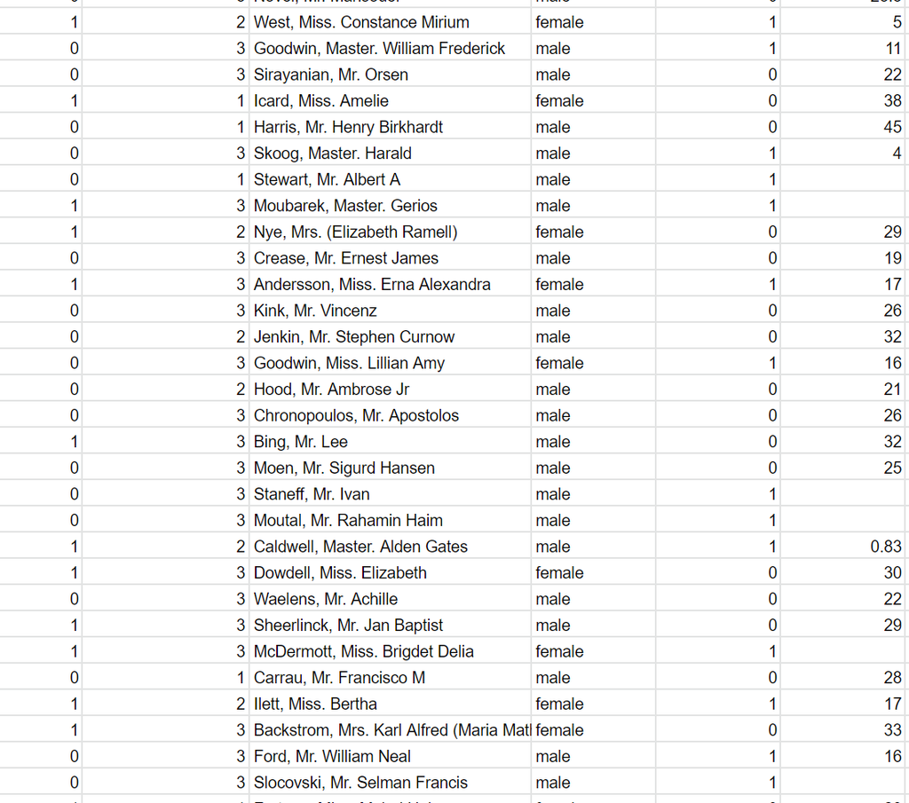

```python
Image(filename='./images/missing_data_age.PNG')
```

> 맨 오른편이 Age feature data이고 곳곳에 빠진 데이터와 소숫점 나이 데이터(0.83처럼 튀는 데이터)가 보이는 것을 확인할 수 있다.

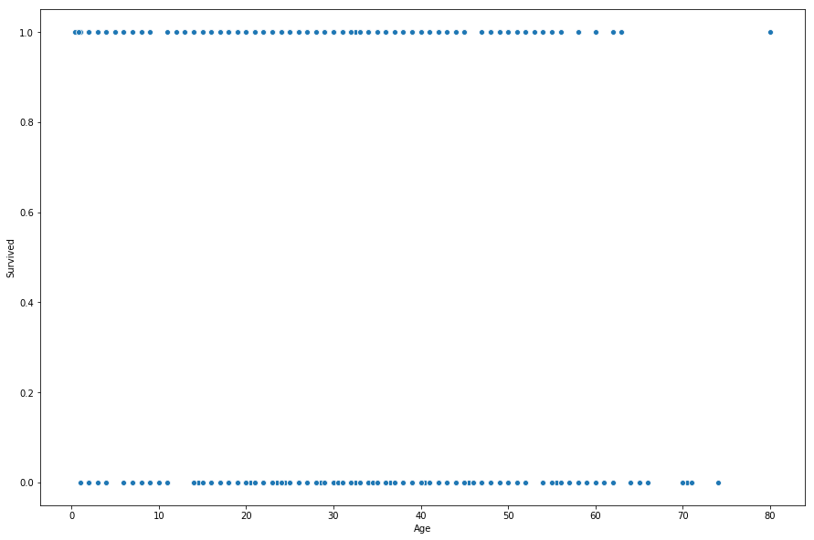

```python
# Scatterplot 사용해보기
# Age와 Survived 간의 상관관계를 나타내는 시각화 진행해보기(hue = Survived)
# fit_reg이 false인 이유 : 선형회귀여부가 필요 없으므로(어디로 상관관계가 모이는지가 궁금한 것이 아님, 생존 여부(0, 1)가 궁금)
plt.figure(figsize=(15, 10))
sns.scatterplot(data=train, x="Age", y="Survived")
```

위의 그래프를 있는 그대로 보시면, 연령에 따른 생존 여부는 알기 어렵습니다(연령대별로 다양하게 생존, 사망). 여러가지 유형의 plot을 시도해 보았지만, `Age feature`만 가지고는 뚜렷한 상관관계를 어렵습니다. 고로 다른 feature를 더해보면서 상관관계를 얻어보겠습니다.

### Age(연령)와 Fare(요금) Feature 분석

`Age` 데이터와 더불어 `Fare`(요금) 데이터를 사용해 보도록 하겠습니다. 시각화 했던 방식은 scatterplot을 똑같이 사용해 보도록 하겠습니다.

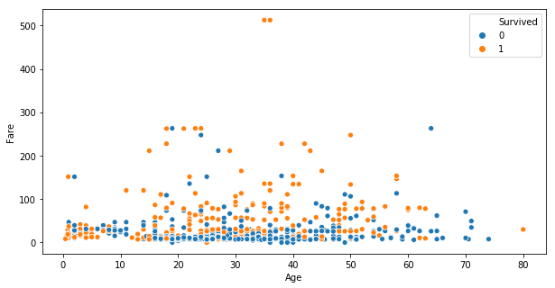

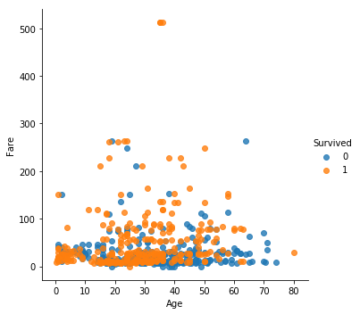

```python
# 앞에 사용했던것과 동일하게 Scatterplot 사용해보기
plt.figure(figsize=(10,5))
sns.scatterplot(data=train, x="Age", y="Fare", hue="Survived")
# lmplot사용해보기
# 회귀선이 기본값으로 설정되어 있습니다. fig_reg=False로 회귀선을 제거해 줍시다.(회귀선 사용 안함)
plt.figure(figsize=(10,5))
sns.lmplot(data=train, x="Age", y="Fare", hue="Survived", fit_reg=False)
```

위 그래프를 보시게 되면 다음과 같은 사실을 얻을 수 있습니다.(어디에 우리가 원하는 데이터의 점이 몰려있는지 보시면 됩니다)

- 유난히 튀는 데이터가 보인다(요금 500이상을 내신 금수저분 몇명)
- `Fare`값의 범위가 넓게 잡혀있어 정확한 상관관계를 예측하기 어렵다

위와 같이 데이터들 중에서 뜬금포 처럼 저 위에 솟아 있거나(Fare를 500 이상 내신 분 처럼) 아래로 눈에 띄게 내려간 데이터들 같은 것을 보고 아웃라이어(Outlier) 라고 합니다 (링크 참조 [outlier](https://en.wikipedia.org/wiki/Outlier)) Outlier값이 얼마 안되지만 저 몇개의 데이터로 인해 시각화를 이용한 분석을 어렵게 만들기도 합니다. 그래서 임시적으로 해당 데이터를 제거하고 다시한번 확인해 보겠습니다.

```python
# Outlier deletion using pandas indexing
# 새로운 변수를 가지고 데이터를 정제하는 이유(원본의 소중함, 잘못하더라도 다시 돌아가서 하기 쉽다)
norm_fare = train[train["Fare"] < 500]

# 실제로 데이터가 잘 만들어 졌는지 확인해 봅니다.
train.shape, norm_fare.shape
```

```
((891, 11), (888, 11))
```

확인 결과 그 몇몇 금수저 분들이 잘 제거됨을 확인 해 볼 수 있습니다. 이제 `norm_data`을 가지고 시각화 분석을 진행해 보겠습니다.

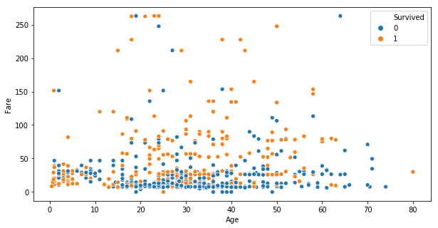

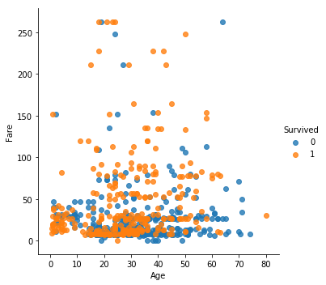

```python
plt.figure(figsize=(10,5))
sns.scatterplot(data=norm_fare, x="Age", y="Fare", hue="Survived")
sns.lmplot(data=norm_fare, x="Age", y="Fare", hue="Survived", fit_reg=False)
```

Outlier를 제거하고 살펴보니 `Fare` 및 `Age`와 `Survived`의 상관관계에서 이런 사실들을 얻을 수 있습니다.

- 요금을 많이 낼 수록 생존할 확률이 높다
- 연령이 어릴수록 생존할 확률이 높다(0~10세 사이를 살펴보면 살아남은 어린이들이 많이 보입니다)
- 연령에 따른 요금에 대한 상관관계는 큰 의미가 없을 듯 합니다.(원래 돈 많은 사람은 적다 많지 않고....)

좀 더 다수에 해당하는 사람들의 생존 여부를 확인하기 위해 아웃라이어로 설정한 범위를 낮춰 보겠습니다.

```python
low_norm_fare = train[train["Fare"] < 100]

train.shape, norm_fare.shape, low_norm_fare.shape
```

```
((891, 11), (888, 11), (838, 11))
```

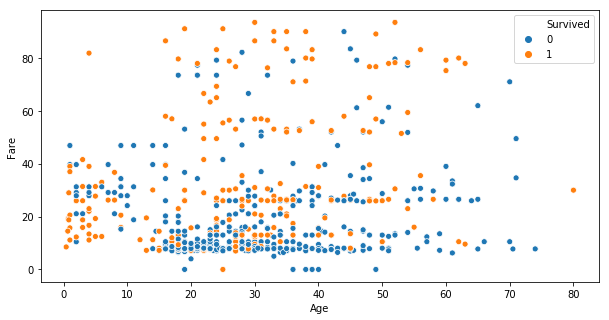

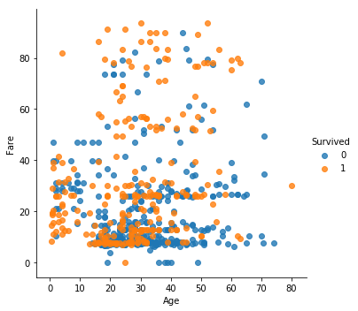

```python
plt.figure(figsize=(10,5))
sns.scatterplot(data=low_norm_fare, x="Age", y="Fare", hue="Survived")
sns.lmplot(data=low_norm_fare, x="Age", y="Fare", hue="Survived", fit_reg=False)
```

아웃라이어를 제거하고, 요금등 스펙트럼이 넓은 데이터에 한하여 범위를 좁힐 수록 데이터 분석을 좀 더 정밀하게 수행할 수 있습니다.

## 정리 및 추후에 진행할 사항, 출처

### 정리 및 추후에 진행할 사항

이상으로 Python을 이용한 Titanic 해상사고 데이터 분석을 진행을 해 보았습니다. 처음 공부하고 일단 도전해 보고 아는 것을 총 동원해서 분석한다는 마음으로 진행을 했는데 하면서도 더 잘하고 싶은 마음도 앞서고 하면서도 아직 많이 부족하다는 것이 느껴져서 복습 및 포스트를 작성하면서도 여러가지를 동시에 깨닫게 됩니다. 이후에는 나머지 분석을 하지 못한 데이터도 마저 분석을 진행해 보고, 본격적으로 분석을 토대로 데이터 전처리 후에 머신러닝 알고리즘을 사용하여 예측 결과를 내는 것 까지 진행해 보겠습니다(목표는 정확도 80% 이상!)

### 출처

- 1. Jupyter notebook 블로그 paste 관련 전처리 : https://versusall.tistory.com/entry/1-Tensor-Flow-%EC%8B%9C%EC%9E%91%ED%95%98%EA%B8%B0-Core-Tutorial?category=749169
- 1. seaborn 데이터 시각화에 대한 한글 정리 자료 : https://brunch.co.kr/@jjason68/12
- 1. seaborn 데이터 시각화에 대한 한글 정리 자료 : https://pinkwink.kr/984
- 1. Jupyter notebook 이미지 첨부 : https://www.slideshare.net/dahlmoon/jupyter-notebok-20160815
- 1. DSschool에서 배운 내용들 참고해서 재구성